# introduction-to-big-data-with-numpy-and-pandas

```python
# This Python 3 environment comes with many helpful analytics libraries installed
# It is defined by the kaggle/python docker image: https://github.com/kaggle/docker-python
# For example, here's several helpful packages to load in

import numpy as np # linear algebra
import pandas as pd # data processing, CSV file I/O (e.g. pd.read_csv)

# Input data files are available in the "../input/" directory.
# For example, running this (by clicking run or pressing Shift+Enter) will list the files in the input directory

import os
print(os.listdir("../input"))

from subprocess import check_output
print(check_output(["ls", "../input"]).decode("utf8"))

# Any results you write to the current directory are saved as output.
```

```
['images', 'world-happiness']
images
world-happiness
```

```
images	world-happiness
```

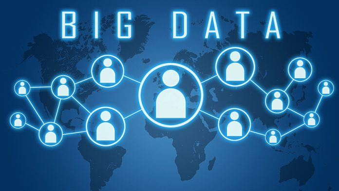

```python
from IPython.display import Image
import os
!ls ../input/

Image("../input/images/bda-696x394.jpg")
```

**BIG DATA ANALYSIS AND MACHINE LEARNING TUTORIAL**

Grasping the Fundamentals Of Big Data-Chapter 1

Big Data Fundamentals

And before starting my tutorial you can have a look at this Youtube video to get a brief idea,  
[Big Data Analytics Video For Beginners-Click On Me](https://www.youtube.com/watch?v=j-0cUmUyb-Y)

Here's some of the books that I can suggest for the beginners :)

| Book | Writers |
| --- | --- |
| Data Science For Dummies | Lillian Pierson |
| Big Data For Dummies | A Wiley Brand |
| Python Data Science Handbook | Jake VanderPlas |
| R for Data Science | Garret Grolemund and Hadley Wickham |
| Introduction to Statistical Learning | Gareth James, Daniela Witten, Trevor Hastie, and Robert Tibshirani |
| The Elements of Statistical Learning | Trevor Hastie, Robert Tibshirani, Jerome Friedman |
| Mining of Massive Datasets | Jure Leskovec, Anand Rajaraman, Jeff Ullman |

As we go on to this tutorial I'll also suggest the books in the field of machine learning and deep learning and I'll share the projects that I've created, with you.Don't forget to write comments.If you have any suggestions as a book,you can share with me.I'd like to hear from you :)

Let's start with the heeadings we'll discuss at the beginning.

**1.**History of data Management  
**2.**Understanding why big data matters to business  
**3.**Applying big data to business effectiveness  
**4.**Defining the fundamental elements of big data  
**5.**Examining the big data's role in future

Around 2005, people began to realize just how much data users generated through **Facebook**, **YouTube**, and other online services. **Hadoop** (an open-source framework created specifically to store and analyze big data sets) was developed that same year. **NoSQL** also began to gain popularity during this time.

The development of open-source frameworks, such as Hadoop (and more recently, Spark) was essential for the growth of big data because they make big data easier to work with and cheaper to store. In the years since then, the volume of big data has skyrocketed. Users are still generating huge amounts of data—but it’s not just humans who are doing it.

With the advent of the **Internet of Things (IoT)**, more objects and devices are connected to the internet, gathering data on customer usage patterns and product performance. The emergence of **machine learning** has produced still more data.

```
images	world-happiness
```

[figure not shown]

```python
from IPython.display import Image
import os
!ls ../input/

Image("../input/images/history-bigdata.jpg")
```

Managing and analyzing big data have always offered the greatest benefits and the greatest challenges for organizations of all sizes and across all industries.Businesses have long struggled with finding a pragmatic approach to capturing information about customers ,products and services.Over time companies and markets they participate in have grown more complicated.

To **survive or gain a competitive advantage with customers** , these companies added more product lines and diversified how they deliver their product.Data struggles are not limited to business.Research and development ( R&D ) organizations,for example,have struggled to get enough computing power to run sophisticated models or to process images and other sources or scientific data.

Indeed,we are dealing with a lot of complexity when it comes to data.Some data is **structured** and stored in a traditional relational database,while other data ,including documents ,customer service records,and even pictures and videos,is **unstructured**.Companies also have to consider new sources of data generated by machines such as sensors.Other new sources are human generated from website interactions .

So,We can classify the data into three groups **structured,unstructrured ans semi-structured.**To explain differences I've created a table.

When you are dealing with so much information in so many different forms ,it is impossible to think about data management in traditional ways. A precise specification of ‘big’ is elusive. What is considered big for one organization may be small for another. What is large-scale today will likely seem small-scale in the near future; petabyte is the new terabyte. Thus, size alone cannot specify big data. The complexity of the data is an important factor that must also be considered.

| Properties | Structured | Semi-structured | Unstructured |
| --- | --- | --- | --- |
| Technology | It is based on Relational database table | It is based on XML/RDF | It is based on character and binary data |
| Transaction management | Matured transaction and various concurrency technique | Transaction is adapted from DBMS not matured | No transaction management and no concurrency |
| Version management | Versioning over tuples,row,tables | Versioning over tuples or graph is possible | Versioned as whole |
| Flexibility | It is sehema dependent and less flexible | It is more flexible than structuded data but less than flexible than unstructured data | it very flexible and there is abbsence of schema |
| Scalability | It is very difficult to scale DB schema | It’s scaling is simpler than sstructured data | It is very scalable |
| Robustness | Very robust | New technology, not very spread | --- |
| Query performance | Structured query allow complex joining | Queries over anonymous nodes are possible | Only textual query are possible |

Now I'll explain the characteristics of Big Data

The Characteristics Of Big Data

```
images	world-happiness
```

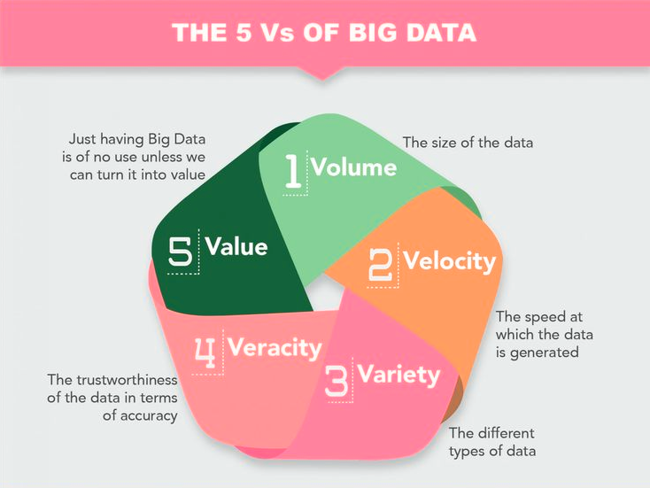

```python
from IPython.display import Image
import os
!ls ../input/

Image("../input/images/threev.png")
```

# Volume

Refers to the vast amounts of data generated every second. Just think of all the emails, twitter messages, photos, video clips, sensor data etc. we produce and share every second. We are not talking Terabytes but Zettabytes or Brontobytes. On Facebook alone we send 10 billion messages per day, click the “like’ button 4.5 billion times and upload 350 million new pictures each and every day. If we take all the data generated in the world between the beginning of time and 2008, the same amount of data will soon be generated every minute! This increasingly makes data sets too large to store and analyse using traditional database technology. With big data technology we can now store and use these data sets with the help of distributed systems, where parts of the data is stored in different locations and brought together by software.

# Velocity

Refers to the speed at which new data is generated and the speed at which data moves around. Just think of social media messages going viral in seconds, the speed at which credit card transactions are checked for fraudulent activities, or the milliseconds it takes trading systems to analyse social media networks to pick up signals that trigger decisions to buy or sell shares. Big data technology allows us now to analyse the data while it is being generated, without ever putting it into databases.

# Variety

Refers to the different types of data we can now use. In the past we focused on structured data that neatly fits into tables or relational databases, such as financial data (e.g. sales by product or region). In fact, 80% of the world’s data is now unstructured, and therefore can’t easily be put into tables (think of photos, video sequences or social media updates). With big data technology we can now harness differed types of data (structured and unstructured) including messages, social media conversations, photos, sensor data, video or voice recordings and bring them together with more traditional, structured data.

# Veracity

Refers to the messiness or trustworthiness of the data. With many forms of big data, quality and accuracy are less controllable (just think of Twitter posts with hash tags, abbreviations, typos and colloquial speech as well as the reliability and accuracy of content) but big data and analytics technology now allows us to work with these type of data. The volumes often make up for the lack of quality or accuracy.

# Value

Then there is another V to take into account when looking at Big Data: Value! It is all well and good having access to big data but unless we can turn it into value it is useless. So you can safely argue that ‘value’ is the most important V of Big Data. It is important that businesses make a business case for any attempt to collect and leverage big data. It is so easy to fall into the buzz trap and embark on big data initiatives without a clear understanding of costs and benefits.

So,briefly:

**Volume:** This refers to the vast amounts of data that is generated every second/minute/hour/day in our digitized world.

**Velocity:** This refers to the speed at which data is being generated and the pace at which data moves from one point to the next.

**Variety:** This refers to the ever-increasing different forms that data can come in, e.g., text, images, voice, geospatial.

**Veracity:** This refers to the quality of the data, which can vary greatly.

**Value:** Processing big data must bring about value from insights gained.

```
images	world-happiness
```

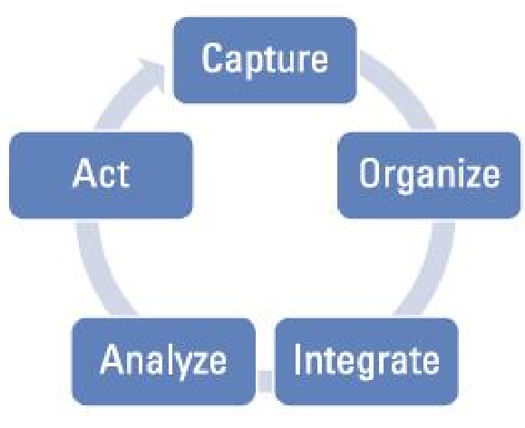

```python
from IPython.display import Image
import os
!ls ../input/

Image("../input/images/Management.png")
```

**Building a Successful Big Data Management Architecture**

The above figure illustrates that data must first be captured,and then organized and integrated.After this pase is successfully implemented,data can be analyzed based on the problem being addressed.Finally,management takes action based on the outcome of that analysis.For exmple, Amazon.com might recommend a book based on a past purchase or a customer might receive a coupon for a discount for a future purchase of a related product to one that was just purchased.Although this sounds straightforward,certain nuances of these functions are complicated.Validation is a particularly important issue.If your organization is combining data sources,it is critical that you have the ability to validate that these sources make sense when combined.

**Exploring sources of big structured data**

**Machine Generated Data:**  
->Computer or machine generated  
->Human Generated  
->Sensor Data  
->Web Log Data  
->Point Of Sale Data  
->Financial Data

**Human Generated:**  
->Input Data  
->Click-stream data  
->Gaming related data

**Exploring sources of big unstructured data**

**Machine Generated Data**  
->Satellite Images  
->Scientific Data  
->Photograph and Video  
->Radar and Sonar data  
**Human-Generated Data**  
->Text internal to your company  
->Social Media Data  
->Mobile Data  
->Website Content

```
images	world-happiness
```

[figure not shown]

```python
from IPython.display import Image
import os
!ls ../input/

Image("../input/images/company.jpg")
```

**Big data** is **big** business. Eleanor O'Neill takes a look at ten of the companies using data and analytics to gain a competitive edge. The term 'big data' refers to extremely large sets of digital data that may be analysed to reveal patterns, trends and associations relating to human behaviour and interactions.

Companies can use this information to their advantage; automating processes, gaining insight into their target market and improving overall performance using the feedback readily available.

Here we look at some of the businesses integrating big data and how they are using it to boost their brand success.

1. Amazon

The online retail giant has access to a massive amount of data on its customers; names, addresses, payments and search histories are all filed away in its data bank.

While this information is obviously put to use in advertising algorithms, Amazon also uses the information to improve customer relations, an area that many big data users overlook.

The next time you contact the Amazon help desk with a query, don't be surprised when the employee on the other end already has most of the pertinent information about you on hand. This allows for a faster, more efficient customer service experience that doesn't include having to spell out your name three times.

2. American Express

The American Express Company is using big data to analyse and predict consumer behaviour.

By looking at historical transactions and incorporating more than 100 variables, the company employs sophisticated predictive models in place of traditional business intelligence-based hindsight reporting.

This allows a more accurate forecast of potential churn and customer loyalty. In fact, American Express has claimed that, in their Australian market, they are able to predict 24% of accounts that will close within four months.

3. BDO

National accounting and audit firm BDO puts big data analytics to use in identifying risk and fraud during audits.

Where, in the past, finding the source of a discrepancy would involve numerous interviews and hours of manpower, consulting internal data first allows for a significantly narrowed field and streamlined process.

In one case, BDO Consulting Director Kirstie Tiernan noted, they were able to cut a list of thousands of vendors down to a dozen and, from there, review data individually for inconsistencies. A specific source was identified relatively quickly.

4. Capital One

Marketing is one of the most common uses for big data and Capital One are at the top of the game, utilising big data management to help them ensure the success of all customer offerings.

Through analysis of the demographics and spending habits of customers, Capital One determines the optimal times to present various offers to clients, thus increasing the conversion rates from their communications.

Not only does this result in better uptake but marketing strategies become far more targeted and relevant, therefore improving budget allocation.

5. General Electric (GE)

GE is using the data from sensors on machinery like gas turbines and jet engines to identify ways to improve working processes and reliability.

The resultant reports are then passed to GE's analytics team to develop tools and improvements for increased efficiency.

The company has estimated that data could boost productivity in the US by 1.5%, which, over a 20-year period, could save enough cash to raise average national incomes by as much as 30%.

6. Miniclip

Miniclip, who develop, publish and distribute digital games globally, use big data to monitor and improve user experience.

Due to the nature of the company and sector, customer retention is a priority for Miniclip in order to make games more profitable and, therefore, to support business growth.

Big data reporting, analysis, experimentation and machine learning data products allow the company to measure the successful elements of their products and implement them in future ventures, while also eliminating or improving the problematic components.

7. Netflix

The entertainment streaming service has a wealth of data and analytics providing insight into the viewing habits of millions of international consumers.

Netflix uses this data to commission original programming content that appeals globally as well as purchasing the rights to films and series boxsets that they know will perform well with certain audiences.

For example, Adam Sandler has proven unpopular in the US and UK markets in recent years but Netflix green-lighted four new films with the actor in 2015, armed with the knowledge that his previous work had been successful in Latin America.

8. Next Big Sound

Next Big Sound (NBS) has figured out how to use the data from Spotify streams, iTunes sales, SoundCloud plays, Facebook likes, Wikipedia page views, YouTube hits and Twitter mentions to predict the next big thing in music.

The company's analytics provide insight into social media popularity, the impact of TV appearances and many other nuggets of information that are invaluable to the music industry. Artists can also use the data for their own promotion, thanks to a partnership between NBS and Spotify.

Billboard now publishes two charts based exclusively on NBS’s data and they have worked with companies such as Pepsi and American Express to help steer billions being spent brands on music-related marketing and sponsorships.

9. Starbucks

Have you ever wondered how Starbucks can open three branches on the same street and not have their business suffer?

The coffeehouse behemoth uses big data to determine the potential success of each new location, taking information on location, traffic, area demographic and customer behaviour into account.

Making this kind of assessment before opening a store means Starbucks can make a fairly accurate estimation of what the success rate will be and choose locations based on the propensity toward revenue growth.

10. T-Mobile

The mobile network, like American Express, is combining customer transaction and interactions data to predict customer fluctuations.

By utilising internal information on billing and customer relations management along with data on social media usage, T-Moblie USA claims they halved customer defections within a single quarter.

The company has integrated the data gathering tools across its' IT systems.

```
images	world-happiness
```

[figure not shown]

```python
from IPython.display import Image
import os
!ls ../input/

Image("../input/images/Trump_New_York_Times_tweet_.jpg")
```

**Yao Yue** has worked on Twitter’s Cache team since 2010. She recently gave a really great talk: Scaling Redis at Twitter. It’s about Redis of course, but it's not just about Redis.

Yao has worked at Twitter for a few years. She's seen some things. She’s watched the growth of the cache service at Twitter explode from it being used by just one project to nearly a hundred projects using it. That's many thousands of machines, many clusters, and many terabytes of RAM.

It's clear from her talk that's she's coming from a place of real personal experience and that shines through in the practical way she explores issues. It's a talk well worth watching.

As you might expect, Twitter has a lot of cache.  
**Why Redis?**  
Redis drives Timeline, Twitter’s most important service. Timeline is an index of tweets indexed by an id. Chaining tweets together in a list produces the Home Timeline. The User Timeline, which consists of tweets the user has tweeted, is just another list.

Why consider Redis instead of Memcache? The Network Bandwidth Problem and The Long Common Prefix Problem.

**The Trade-offs**

Here I want to give some info about trade-offs but not in detail.If you wanna get more you can just click on the link that I've provided at the end of this part of our discussion.

Performance vs Scalability

How Do I Know If I Have a Performance problem ?  
If your system is slow for a single user.

How Do I Know If I Have a Scalability problem ?  
If your system is fast for a single userbut slow under heavy load.

Latency vs Throughput

You should strive for maximal throughput with acceptable latency

Availability vs Consistency

Brewer's CAP Theorem

You can only pick two :

Consistency

Availability

Partition Tolarance

At a point given in time.  
In a Centralized System:(RDBMS)-We don't have network partitions( P ) in CAP.So you get both Availability and Consistency.Atomic,Consistent,Isolated,Durable.  
In a Distributed System:We have network partitions( P ) in CAP.So you get to only pick one of Availability and Consistency.  
So, there are two types of systems :

CP and AP

There is only one choice to make.In case of a network partition,what do you sacrifice ?Consistency or Availability.( Basically Available,Soft State,Eventually Consistent )

Availability Patterns

1.Fail Over( Normal Operation----Failure Occurs------>Fail Over-----Service Restored--->Normal Operation )  
2.Replication( Active Replication(Pull),Passive Replication(Pull-Data not available read from peer store it locally,Works well with timeout based caches )  
2.1 Master-Slave  
2.2Tree-Replication  
2.3 Master-Master  
2.4 Buddy-Replication

How to scale out RDBMS ? Sharding:Partitioning and Sharding:Replication

I'm not going into detail.If you want to get more information about these topic here's the link,

[Trade-Offs Slide Share](https://www.slideshare.net/jboner/scalability-availability-stability-patterns/64-Think_about_your_data_When)

The best languages for big data - Chapter 2

1.Why use Scala for big data? :)

->Fast and robust  
->Suitable for working with Big Data tools like Apache Spark for distributed Big Data processing  
->JVM compliant, can be used in a Java-based ecosystem

2.Why use Python for big data?:)

General-purpose  
Rich libraries for data analysis and machine learning  
Easy to use  
Supports iterative development  
Rich integration with Big Data tools  
Interactive computing through Jupyter notebooks

4.Why use R for big data? :)

Built for data science  
Support for Hadoop and Spark  
Strong statistical modeling and visualization capabilities  
Support for Jupyter notebooks

5.Why use Java for big data?:)

Traditional Big Data tools and frameworks are written in Java  
Stable and production-ready  
Large ecosystem of tried and tested tools and libraries

6.Why use Go for big data?

Fast, easy to use  
Many tools used in the Big Data infrastructure are Go-based  
Efficient distributed computing  
**So…which language should you choose?**  
To answer the question in short – it all depends on the use-case you want to develop. If your focus is hardcore data analysis which involves a lot of statistical computing, **R** would be your go-to language. On the other hand, if you want to develop streaming applications for your Big Data, **Scala** can be a preferable choice. If you wish to use **Machine Learning** to leverage your Big Data and build predictive models, Python will come to your rescue. Lastly, if you plan to build Big Data solutions using just the traditionally-available tools, **Java** is the language for you.I'm going to use python for this tutorial so if you don't know python well you can learn at this link below: [You can learn Python easily by cliking on this link](https://www.w3schools.com/python/) And I'll use **numpy,pandas,matplotlib,seaborn and plotly** for the first kernel that we are going to create.So let's get an idea about them together.

**NUMPY**